# NCLDV and Giant Virus Isolate Glossary

Alex Truchon

7/21/2020

## Canarypox virus strain ATCC VR-111

#### *Poxviruses*

AY318871

https://www.ncbi.nlm.nih.gov/nuccore/AY318871

## Choristoneura biennis entomopoxvirus ‘L’

#### *Poxviruses*

HF679132

https://www.ncbi.nlm.nih.gov/nuccore/HF679132

## Penguinpox virus isolate PSan92

#### *Poxviruses*

KJ859677

https://www.ncbi.nlm.nih.gov/nuccore/KJ859677

## Flamingopox virus FGPVKD09

#### *Poxviruses*

MF678796

https://www.ncbi.nlm.nih.gov/nuccore/MF678796

## Fowlpox virus

#### *Poxviruses*

AF198100

https://www.ncbi.nlm.nih.gov/nuccore/AF198100

## Choristoneura rosaceana entomopoxvirus ‘L’

#### *Poxviruses*

HF679133

https://www.ncbi.nlm.nih.gov/nuccore/HF679133

## Pigeonpox virus isolate FeP2

#### *Poxviruses*

KJ801920

https://www.ncbi.nlm.nih.gov/nuccore/KJ801920

## Mythimna separata entomopoxvirus ‘L’

#### *Poxviruses*

HF679134

https://www.ncbi.nlm.nih.gov/nuccore/HF679134

## Anomala cuprea entomopoxvirus DNA CV6M

#### *Poxviruses*

AP013055

https://www.ncbi.nlm.nih.gov/nuccore/AP013055

## Salmon gill poxvirus

#### *Poxviruses*

KT159937

https://www.ncbi.nlm.nih.gov/nuccore/KT159937

## Melanoplus sanguinipes entomopoxvirus ‘O’ isolate Tucson

#### *Poxviruses*

AF063866

https://www.ncbi.nlm.nih.gov/nuccore/AF063866

## Amsacta moorei entomopoxvirus

#### *Poxviruses*

AF250284

https://www.ncbi.nlm.nih.gov/nuccore/AF250284

## Adoxophyes honmai enomopoxvirus ‘L’

#### *Poxviruses*

HF679131

https://www.ncbi.nlm.nih.gov/nuccore/HF679131

## Cowpox virus strain Brighton Red

#### *Poxviruses*

AF482758

https://www.ncbi.nlm.nih.gov/nuccore/AF482758

## Skunkpox virus strain WA

#### *Poxviruses*

KU749310

https://www.ncbi.nlm.nih.gov/nuccore/KU749310

## Volepox virus strain CA

#### *Poxviruses*

KU749311

https://www.ncbi.nlm.nih.gov/nuccore/KU749311

## Raccoonpox virus

#### *Poxviruses*

NC027213

https://www.ncbi.nlm.nih.gov/nuccore/NC027213

## Ectromelia virus strain Moscow

#### *Poxviruses*

AF012825

https://www.ncbi.nlm.nih.gov/nuccore/AF012825

## Camelpox virus CMS

#### *Poxviruses*

AY009089

https://www.ncbi.nlm.nih.gov/nuccore/AY009089

## Camelpox virus GVMAG-M-96 from Kazakhstan

#### *Poxviruses*

AF438165

https://www.ncbi.nlm.nih.gov/nuccore/AF438165

## Murmansk poxvirus strain LEIV-11411

#### *Poxviruses*

MF001304

https://www.ncbi.nlm.nih.gov/nuccore/MF001304

## NY_014 poxvirus strain 2013

#### *Poxviruses*

MF001305

https://www.ncbi.nlm.nih.gov/nuccore/MF001305

## Taterapox virus

#### *Poxviruses*

NC008291

https://www.ncbi.nlm.nih.gov/nuccore/NC008291

## Taterapox virus strain Dahomey 1968

#### *Poxviruses*

DQ437594

https://www.ncbi.nlm.nih.gov/nuccore/DQ437594

## Monkeypox virus strain Zaire-96-I-16

#### *Poxviruses*

AF380138

https://www.ncbi.nlm.nih.gov/nuccore/AF380138

## Vaccinia virus WR

#### *Poxviruses*

AY243312

https://www.ncbi.nlm.nih.gov/nuccore/AY243312

## Molluscum contagiosum virus subtype 1

#### *Poxviruses*

NC_001731

https://www.ncbi.nlm.nih.gov/nuccore/NC_001731

## Nile crocodilepox virus

#### *Poxviruses*

DQ356948

https://www.ncbi.nlm.nih.gov/nuccore/DQ356948

## Turkeypox virus strain TKPV-HU1124/2011

#### *Poxviruses*

KP728110

https://www.ncbi.nlm.nih.gov/nuccore/KP728110

## Variola virus DNA

#### *Poxviruses*

NC_001611

https://www.ncbi.nlm.nih.gov/nuccore/NC_001611

## Cotia virus SPAn232

#### *Poxviruses*

HQ647181

https://www.ncbi.nlm.nih.gov/nuccore/HQ647181

## Eptesipox virus strain Washington

#### *Poxviruses*

KY747497

https://www.ncbi.nlm.nih.gov/nuccore/KY747497

## Yoka poxvirus

#### *Poxviruses*

NC015960

https://www.ncbi.nlm.nih.gov/nuccore/NC015960

## Yoka poxvirus strain DakArB 4268

#### *Poxviruses*

HQ849551

https://www.ncbi.nlm.nih.gov/nuccore/HQ849551

## Deerpox virus W-1170-84

#### *Poxviruses*

AY841896

https://www.ncbi.nlm.nih.gov/nuccore/AY841896

## Deerpox virus W-848-83

#### *Poxviruses*

AY689436

https://www.ncbi.nlm.nih.gov/nuccore/AY689436

## BeAn 58058 virus

#### *Poxviruses*

KY094066

https://www.ncbi.nlm.nih.gov/nuccore/KY094066

## Myxoma virus strain Lausanne

#### *Poxviruses*

AF170726

https://www.ncbi.nlm.nih.gov/nuccore/AF170726

## Rabbit fibroma virus

#### *Poxviruses*

AF170722

https://www.ncbi.nlm.nih.gov/nuccore/AF170722

## Lumpy skin disease virus NI-2490 isolate Neethling 2490

#### *Poxviruses*

AF325528

https://www.ncbi.nlm.nih.gov/nuccore/AF325528

## Sheeppox virus 10700-99 strain TU-V02127

#### *Poxviruses*

AY077832

https://www.ncbi.nlm.nih.gov/nuccore/AY077832

## Goatpox virus Pellor

#### *Poxviruses*

AY077835

https://www.ncbi.nlm.nih.gov/nuccore/AY077835

## Squirrel poxvirus strain Red squirrel UK

#### *Poxviruses*

HE601899

https://www.ncbi.nlm.nih.gov/nuccore/HE601899

## Swinepox virus isolate 17077-99

#### *Poxviruses*

AF410153

https://www.ncbi.nlm.nih.gov/nuccore/AF410153

## Pseudocowpox virus strain VR634

#### *Poxviruses*

GQ329670

https://www.ncbi.nlm.nih.gov/nuccore/GQ329670

## Yaba-like disease virus (YLDV)

#### *Poxviruses*

AJ293568

https://www.ncbi.nlm.nih.gov/nuccore/AJ293568

## Squirrelpox virus Berlin_2015

#### *Poxviruses*

MF503315

https://www.ncbi.nlm.nih.gov/nuccore/MF503315

## Parapoxvirus red deer/HL953 strain HL953

#### *Poxviruses*

KM502564

https://www.ncbi.nlm.nih.gov/nuccore/KM502564

## Orf virus strain OV-SA00

#### *Poxviruses*

AY386264

https://www.ncbi.nlm.nih.gov/nuccore/AY386264

## Yaba monkey tumor virus

#### *Poxviruses*

AY386371

https://www.ncbi.nlm.nih.gov/nuccore/AY386371

## Bovine papular stomatitis virus strain BV-AR02

#### *Poxviruses*

AY386265

https://www.ncbi.nlm.nih.gov/nuccore/AY386265

## Pteropox virus strain Australia

#### *Poxviruses*

KU980965

https://www.ncbi.nlm.nih.gov/nuccore/KU980965

## Seal parapoxvirus isolate AFK76s1

#### *Poxviruses*

KY382358

https://www.ncbi.nlm.nih.gov/nuccore/KY382358

## Sea otter poxvirus strain ELK

#### *Poxviruses*

MH427217

https://www.ncbi.nlm.nih.gov/nuccore/MH427217

## African swine fever virus Georgia 20071

#### *Asfarviruses*

FR682468

https://www.ncbi.nlm.nih.gov/nuccore/FR682468

## African swine fever virus Malawi LIL 201

#### *Asfarviruses*

AY261361

https://www.ncbi.nlm.nih.gov/nuccore/AY261361

## African swine fever virus BA71V

#### *Asfarviruses*

NC001659

https://www.ncbi.nlm.nih.gov/nuccore/NC001659

## Faustovirus LC9

#### *Faustoviruses*

CZDJ02000001

https://www.ncbi.nlm.nih.gov/nuccore/CZDJ02000001

## Faustovirus E12

#### *Faustoviruses*

KJ614390

https://www.ncbi.nlm.nih.gov/nuccore/KJ614390

## Faustovirus D5A

#### *Faustoviruses*

KU702950

https://www.ncbi.nlm.nih.gov/nuccore/KU702950

## Faustovirus E24

#### *Faustoviruses*

KU702948

https://www.ncbi.nlm.nih.gov/nuccore/KU702948

## Faustovirus E23

#### *Faustoviruses*

KU702952

https://www.ncbi.nlm.nih.gov/nuccore/KU702952

## Faustovirus D5B

#### *Faustoviruses*

KU702949

https://www.ncbi.nlm.nih.gov/nuccore/KU702949

## Faustovirus D6

#### *Faustoviruses*

KU702951

https://www.ncbi.nlm.nih.gov/nuccore/KU702951

## Faustovirus D3

#### *Faustoviruses*

KU556803

https://www.ncbi.nlm.nih.gov/nuccore/KU556803

## Kaumoebavirus isolate Sc

#### *Kaumoebaviruses*

KX552040

https://www.ncbi.nlm.nih.gov/nuccore/KX552040

## Pacmanvirus A23

#### *Pacmanviruses*

NC_034383

https://www.ncbi.nlm.nih.gov/nuccore/NC_034383

## Aureococcus anophagefferens virus btv-01

#### *Aureococcusviruses*

NC024697

https://www.ncbi.nlm.nih.gov/nuccore/NC024697

## Tetraselmis virus 1

#### *Tetraselmisviruses*

KY322437

https://www.ncbi.nlm.nih.gov/nuccore/KY322437

## Heliothis virescens ascovirus 3g

#### *Ascoviruses*

JX491653

https://www.ncbi.nlm.nih.gov/nuccore/JX491653

## Heliothis virescens ascovirus 3f

#### *Ascoviruses*

KJ755191

https://www.ncbi.nlm.nih.gov/nuccore/KJ755191

## Heliothis virescens ascovirus 3e

#### *Ascoviruses*

NC009233

https://www.ncbi.nlm.nih.gov/nuccore/NC009233

## Trichoplusia ni ascovirus 6b

#### *Ascoviruses*

KY434117

https://www.ncbi.nlm.nih.gov/nuccore/KY434117

## Trichoplusia ni ascovirus 2c

#### *Ascoviruses*

NC_008518

https://www.ncbi.nlm.nih.gov/nuccore/NC_008518

## Cherax quadricarinatus iridovirus CQIV-CN01

#### *Ascoviruses*

MF197913

https://www.ncbi.nlm.nih.gov/nuccore/MF197913

## Spodoptera frugiperda ascovirus 1a

#### *Ascoviruses*

NC_008361

https://www.ncbi.nlm.nih.gov/nuccore/NC_008361

## Scale drop disease virus isolate C4575

#### *Ascoviruses*

NC_027778

https://www.ncbi.nlm.nih.gov/nuccore/NC_027778

## Diadromus pulchellus ascovirus 4a

#### *Ascoviruses*

NC_011335

https://www.ncbi.nlm.nih.gov/nuccore/NC_011335

## Ranavirus maximus isolate SMA15001

#### *Ascoviruses*

NC_030842

https://www.ncbi.nlm.nih.gov/nuccore/NC_030842

## Chinese giant salamander iridovirus CGSIV-HN1104

#### *Ascoviruses*

KF512820

https://www.ncbi.nlm.nih.gov/nuccore/KF512820

## A. vulgare iridescent virus 31

#### *Iridoviruses*

NC024451

https://www.ncbi.nlm.nih.gov/nuccore/NC024451

## Invertebrate iridescent virus 6

#### *Iridoviruses*

NC003038

https://www.ncbi.nlm.nih.gov/nuccore/NC003038

## Wiseana iridescent virus

#### *Iridoviruses*

NC015780

https://www.ncbi.nlm.nih.gov/nuccore/NC015780

## Invertebrate iridovirus 25

#### *Iridoviruses*

NC023613

https://www.ncbi.nlm.nih.gov/nuccore/NC023613

## Invertebrate iridovirus 30

#### *Iridoviruses*

NC023611

https://www.ncbi.nlm.nih.gov/nuccore/NC023611

## Invertebrate iridovirus 22

#### *Iridoviruses*

NC021901

https://www.ncbi.nlm.nih.gov/nuccore/NC021901

## Anopheles minimus irodovirus isolate AMIV

#### *Iridoviruses*

NC_023848

https://www.ncbi.nlm.nih.gov/nuccore/NC_023848

## Tunisvirus fontaine2 U484

#### *Marseilleviruses*

KF483846

https://www.ncbi.nlm.nih.gov/nuccore/KF483846

## Noumeavirus NMV1

#### *Marseilleviruses*

NC033775

https://www.ncbi.nlm.nih.gov/nuccore/NC033775

## Tokyovirus A1

#### *Marseilleviruses*

NC030230

https://www.ncbi.nlm.nih.gov/nuccore/NC030230

## Melbournevirus

#### *Marseilleviruses*

NC025412

https://www.ncbi.nlm.nih.gov/nuccore/NC025412

## Marseillevirus marseillevirus t19

#### *Marseilleviruses*

NC013756

https://www.ncbi.nlm.nih.gov/nuccore/NC013756

## Brazilian marseillevirus BH2014

#### *Marseilleviruses*

NC029692

https://www.ncbi.nlm.nih.gov/nuccore/NC029692

## Golden Marseillevirus

#### *Marseilleviruses*

NC_031465

https://www.ncbi.nlm.nih.gov/nuccore/NC_031465

## Port-miou virus

#### *Marseilleviruses*

KT428292

https://www.ncbi.nlm.nih.gov/nuccore/KT428292

## Lausannevirus

#### *Marseilleviruses*

NC015326

https://www.ncbi.nlm.nih.gov/nuccore/NC015326

## Orpheovirus IHUMI-LCC2

#### *Orpheoviruses*

NC_036594

https://www.ncbi.nlm.nih.gov/nuccore/NC_036594

## Pithovirus LC8

#### *Pithocedratviruses*

LT598839

https://www.ncbi.nlm.nih.gov/nuccore/LT598839

## Pithovirus sibericum p1084-t

#### *Pithocedratviruses*

NC023423

https://www.ncbi.nlm.nih.gov/nuccore/NC023423

## Cedratvirus A11

#### *Pithocedratviruses*

NC_032108

https://www.ncbi.nlm.nih.gov/nuccore/NC_032108

## Cedratvirus lausannensis

#### *Pithocedratviruses*

LT907979

https://www.ncbi.nlm.nih.gov/nuccore/LT907979

## Cedratvirus Zaza IHUMI-S29

#### *Pithocedratviruses*

LT994652

https://www.ncbi.nlm.nih.gov/nuccore/LT994652

## Brazilian cedratvirus IHUMI-27.7

#### *Pithocedratviruses*

LT994651

https://www.ncbi.nlm.nih.gov/nuccore/LT994651

## P. bursaria Chlorella virus NY2A

#### *Chloroviruses*

NC009898

https://www.ncbi.nlm.nih.gov/nuccore/NC009898

## P. bursaria chlorella virus ar158

#### *Chloroviruses*

NC009899

https://www.ncbi.nlm.nih.gov/nuccore/NC009899

## P. bursaria Chlorella virus MA-1D

#### *Chloroviruses*

JX997172

https://www.ncbi.nlm.nih.gov/nuccore/JX997172

## P. bursaria chlorella virus 1

#### *Chloroviruses*

NC000852

https://www.ncbi.nlm.nih.gov/nuccore/NC000852

## P. bursaria Chlorella virus CVR-1

#### *Chloroviruses*

JX997164

https://www.ncbi.nlm.nih.gov/nuccore/JX997164

## A. turfacea Chlorella virus OR0704

#### *Chloroviruses*

JX997185

https://www.ncbi.nlm.nih.gov/nuccore/JX997185

## A. turfacea Chlorella virus MO0605SPH

#### *Chloroviruses*

JX997175

https://www.ncbi.nlm.nih.gov/nuccore/JX997175

## A. turfacea Chlorella virus WI0606

#### *Chloroviruses*

JX997187

https://www.ncbi.nlm.nih.gov/nuccore/JX997187

## A. polyphaga moumouvirus

#### *Chloroviruses*

NC020104

https://www.ncbi.nlm.nih.gov/nuccore/NC020104

## E. huxleyi virus 208

#### *Coccolithoviruses*

JF974318

https://www.ncbi.nlm.nih.gov/nuccore/JF974318

## E. huxleyi virus 86

#### *Coccolithoviruses*

NC007346

https://www.ncbi.nlm.nih.gov/nuccore/NC007346

## E. huxleyi virus 201

#### *Coccolithoviruses*

JF974311

https://www.ncbi.nlm.nih.gov/nuccore/JF974311

## Acanthamoeba castellanii medusavirus

#### *Medusaviruses*

AP018495

https://www.ncbi.nlm.nih.gov/nuccore/AP018495

## Mollivirus sibericum p1084t

#### *Molliviruses*

NC027867

https://www.ncbi.nlm.nih.gov/nuccore/NC027867

## Pandoravirus salinus

#### *Pandoraviruses*

NC022098

https://www.ncbi.nlm.nih.gov/nuccore/NC022098

## Pandoravirus inopinatum isolate KlaHel

#### *Pandoraviruses*

NC026440

https://www.ncbi.nlm.nih.gov/nuccore/NC026440

## Pandoravirus quercus

#### *Pandoraviruses*

MG011689

https://www.ncbi.nlm.nih.gov/nuccore/MG011689

## Pandoravirus neocaledonia

#### *Pandoraviruses*

MG011690

https://www.ncbi.nlm.nih.gov/nuccore/MG011690

## Pandoravirus dulcis

#### *Pandoraviruses*

NC021858

https://www.ncbi.nlm.nih.gov/nuccore/NC021858

## Pandoravirus macleodensis

#### *Pandoraviruses*

MG011691

https://www.ncbi.nlm.nih.gov/nuccore/MG011691

## Pandoravirus braziliensis SL2

#### *Pandoraviruses*

LT972217

https://www.ncbi.nlm.nih.gov/nuccore/LT972217

## Pandoravirus pampulha

#### *Pandoraviruses*

OFAJ01000001

https://www.ncbi.nlm.nih.gov/nuccore/OFAJ01000001

## Pandoravirus massiliensis BZ81

#### *Pandoraviruses*

OFAI01000001

https://www.ncbi.nlm.nih.gov/nuccore/OFAI01000001

## Ectocarpus siliculosus virus 1

#### *Phaeoviruses*

NC002687

https://www.ncbi.nlm.nih.gov/nuccore/NC002687

## Feldmannia irregularis virus a

#### *Phaeoviruses*

NC_043254

https://www.ncbi.nlm.nih.gov/nuccore/NC_043254

## Feldmannia species virus

#### *Phaeoviruses*

NC011183

https://www.ncbi.nlm.nih.gov/nuccore/NC011183

## Bathycoccus sp. rcc1105 virus bpv1

#### *Prasinoviruses*

NC014765

https://www.ncbi.nlm.nih.gov/nuccore/NC014765

## O. lucimarinus virus 2 olv2

#### *Prasinoviruses*

NC028091

https://www.ncbi.nlm.nih.gov/nuccore/NC028091

## O. lucimarinus virus olv1

#### *Prasinoviruses*

NC014766

https://www.ncbi.nlm.nih.gov/nuccore/NC014766

## O. mediterraneus virus 1 omv1

#### *Prasinoviruses*

NC028092

https://www.ncbi.nlm.nih.gov/nuccore/NC028092

## O. tauri virus 1

#### *Prasinoviruses*

NC013288

https://www.ncbi.nlm.nih.gov/nuccore/NC013288

## O. tauri virus otv5

#### *Prasinoviruses*

NC010191

https://www.ncbi.nlm.nih.gov/nuccore/NC010191

## O. lucimarinus virus OlV5

#### *Prasinoviruses*

HQ632827

https://www.ncbi.nlm.nih.gov/nuccore/HQ632827

## O. tauri virus 2

#### *Prasinoviruses*

NC014789

https://www.ncbi.nlm.nih.gov/nuccore/NC014789

## Micromonas sp. rcc1109 virus mpv1

#### *Prasinoviruses*

NC014767

https://www.ncbi.nlm.nih.gov/nuccore/NC014767

## O. lucimarinus virus 7 olv7

#### *Prasinoviruses*

NC028093

https://www.ncbi.nlm.nih.gov/nuccore/NC028093

## Heterosigma akashiwo virus 01

#### *Raphidoviruses*

NC_038553

https://www.ncbi.nlm.nih.gov/nuccore/NC_038553

## Cafeteria roenbergensis virus bv-pw1

#### *Cafeteriaviruses*

NC014637

https://www.ncbi.nlm.nih.gov/nuccore/NC014637

## Bodo saltans virus NG

#### *Klosneuviruses*

MF782455

https://www.ncbi.nlm.nih.gov/nuccore/MF782455

## Tupavirus Deep Ocean

#### *Megamimiviruses*

MF405918

https://www.ncbi.nlm.nih.gov/nuccore/MF405918

## Tupavirus Soda Lake

#### *Megamimiviruses*

KY523104

https://www.ncbi.nlm.nih.gov/nuccore/KY523104

## Niemeyer virus

#### *Megamimiviruses*

KT599914

https://www.ncbi.nlm.nih.gov/nuccore/KT599914

## Megavirus chiliensis

#### *Megamimiviruses*

NC016072

https://www.ncbi.nlm.nih.gov/nuccore/NC016072

## Megavirus shan

#### *Megamimiviruses*

LN868520

https://www.ncbi.nlm.nih.gov/nuccore/LN868520

## Megavirus courdo11

#### *Megamimiviruses*

JX975216

https://www.ncbi.nlm.nih.gov/nuccore/JX975216

## Megavirus terra1

#### *Megamimiviruses*

KF527229

https://www.ncbi.nlm.nih.gov/nuccore/KF527229

## Megavirus montpellier3

#### *Megamimiviruses*

LN868518

https://www.ncbi.nlm.nih.gov/nuccore/LN868518

## Megavirus vitis isolate vigne

#### *Megamimiviruses*

MG807319

https://www.ncbi.nlm.nih.gov/nuccore/MG807319

## Afrovirus Urmite69

#### *Megamimiviruses*

CWHP01000001

www.ncbi.nlm.nih.gov/nuccore/CWHP01000001

## Bandra megavirus isolate KK-1

#### *Megamimiviruses*

MG779410

https://www.ncbi.nlm.nih.gov/nuccore/MG779410

## Megavirus lba

#### *Megamimiviruses*

JX885207

https://www.ncbi.nlm.nih.gov/nuccore/JX885207

## Megavirus bus

#### *Megamimiviruses*

LN868539

https://www.ncbi.nlm.nih.gov/nuccore/LN868539

## Megavirus battle43

#### *Megamimiviruses*

LN868256

https://www.ncbi.nlm.nih.gov/nuccore/LN868256

## Acanthamoeba polyphaga mimivirus Kroon

#### *Megamimiviruses*

KM982402

https://www.ncbi.nlm.nih.gov/nuccore/KM982402

## Megavirus T1

#### *Megamimiviruses*

LN868526

https://www.ncbi.nlm.nih.gov/nuccore/LN868526

## Megavirus avenue9

#### *Megamimiviruses*

LN867403

https://www.ncbi.nlm.nih.gov/nuccore/LN867403

## Acanthamoeba polyphaga mimivirus Oyster

#### *Megamimiviruses*

KM982401

https://www.ncbi.nlm.nih.gov/nuccore/KM982401

## Acanthamoeba polyphaga lentillevirus

#### *Megamimiviruses*

AFYC01000000

www.ncbi.nlm.nih.gov/nuccore/AFYC01000000

## A. castellanii mamavirus

#### *Megamimiviruses*

JF801956

https://www.ncbi.nlm.nih.gov/nuccore/JF801956

## Acanthamoeba castellanii mimivirus shirakomae

#### *Megamimiviruses*

AP017645

https://www.ncbi.nlm.nih.gov/nuccore/AP017645

## Acanthamoeba castellanii mimivirus kasaii

#### *Megamimiviruses*

AP017644

https://www.ncbi.nlm.nih.gov/nuccore/AP017644

## Mimivirus Bombay 1

#### *Megamimiviruses*

KU761889

https://www.ncbi.nlm.nih.gov/nuccore/KU761889

## A. polyphaga mimivirus

#### *Megamimiviruses*

NC014649

https://www.ncbi.nlm.nih.gov/nuccore/NC014649

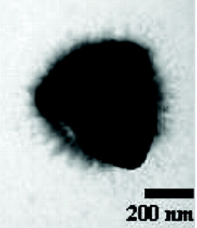

The first known giant virus discovered *La Scola et al., 2003. doi: 10.1126/science.1081867*

## Samba virus

#### *Megamimiviruses*

KF959826

https://www.ncbi.nlm.nih.gov/nuccore/KF959826

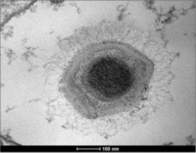

*Campos et al., 2014. doi: 10.1186/1743-422X-11-95*

## Hirudovirus Sangsue

#### *Megamimiviruses*

KF493731

https://www.ncbi.nlm.nih.gov/nuccore/KF493731

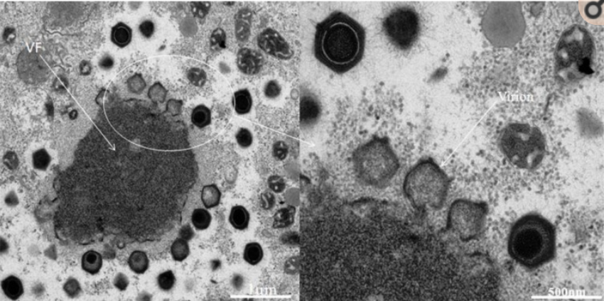

*Boughalmi et al., 2013. doi: 10.3390/v5122920*

## Mimivirus amazonia

#### *Megamimiviruses*

LN867402

https://www.ncbi.nlm.nih.gov/nuccore/LN867402

## Mimivirus terra2

#### *Megamimiviruses*

NC023639

https://www.ncbi.nlm.nih.gov/nuccore/NC023639

## Mimivirus pointerouge1

#### *Megamimiviruses*

LN871174

https://www.ncbi.nlm.nih.gov/nuccore/LN871174

## Mimivirus longchamps

#### *Megamimiviruses*

LN871173

https://www.ncbi.nlm.nih.gov/nuccore/LN871173

## Saudi moumouvirus

#### *Megamimiviruses*

KY110734

https://www.ncbi.nlm.nih.gov/nuccore/KY110734

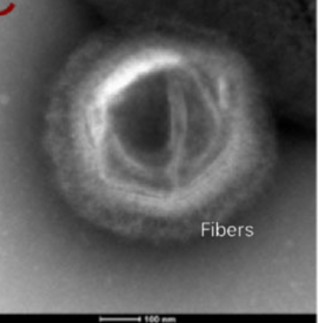

*Bajrai et al., 2016. doi: 10.3389/fmicb.2016.02029*

## Moumouvirus goulette

#### *Megamimiviruses*

KC008572

https://www.ncbi.nlm.nih.gov/nuccore/KC008572

## Moumouvirus Monve

#### *Megamimiviruses*

JN885998

https://www.ncbi.nlm.nih.gov/nuccore/JN885998

## Megavirus T4

#### *Megamimiviruses*

LN869537

https://www.ncbi.nlm.nih.gov/nuccore/LN869537

## Namao virus

#### *Namaoviruses*

MG745875

https://www.ncbi.nlm.nih.gov/nuccore/MG745875

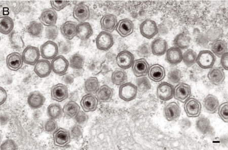

Namao viruses identified in infected sturgeon gill tissue. Scale bar is equivalent to 100 nm. *Clouthier et al., 2013. doi: 10.3354/dao02548*

## Chrysochromulina ericina virus cev-01b

#### *Chrysomulinaviruses*

NC028094

https://www.ncbi.nlm.nih.gov/nuccore/NC028094

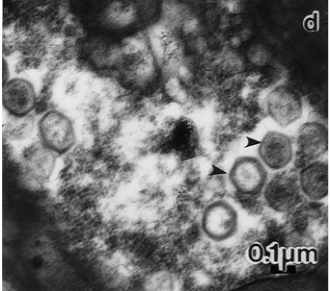

*Sandaa et al., 2001. 10.1006/viro.2001.1161*

## P. globosa virus 12T

#### *Prymnesioviruses*

HQ634147

https://www.ncbi.nlm.nih.gov/nuccore/HQ634147

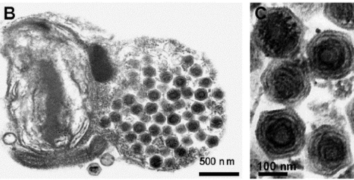

*Baudoux & Brussaard, 2005. doi: 10.1016/j.virol.2005.07.002*

## P. globosa virus 16T

#### *Prymnesioviruses*

KC662249

https://www.ncbi.nlm.nih.gov/nuccore/KC662249

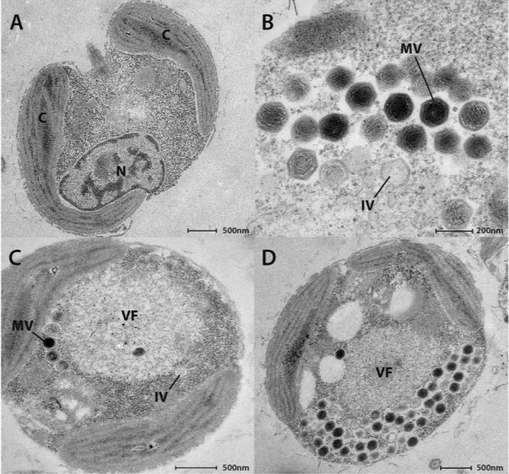

PgV16-T particles at different stages of development: assembly (IV) and mature (MV). *Santini et al., 2013. doi: 10.1073/pnas13032511101*